# HTTP and Requests

Created on Wed Jul 28 05:50:29 2022

@author: David K. Jeremiah

## Objectives

After completing this lab you will be able to:

- Understand HTTP
- Handle HTTP Requests

## Overview of HTTP

HTTP stands for **Hypertext Transfer Protocol**. It is the communication protocol or 'rule' you use whenever you browse the web. It is used in transferring web resources such as HTML documents, images, styles, and other files.

Basically, HTTP is a **request - response** based protocol. A web browser or client (e.g. your laptop) sends an HTTP request to a server, and the webserver sends the HTTP response back to the browser.

## Makeup of an HTTP Request

Next, let's expore the makeup of an HTTP request.

### HTTP requests

##### HTTP methods

The HTTP method describes the type of action that the client wishes to perform. The primary or the most commonly used HTTP methods are **GET**, **POST**, **PUT** and **DELETE**.

The GET method is used to retrieve information from the given server. The POST request method is used to send data to the server. The PUT method updates whatever currently exists on the website with something else. And finally, the DELETE method removes the resources.

##### HTTP path

The **Path** is the *representation* of where the resource is stored on the webserver. For example, if you requested an image at https://example.com/index.html, the path would be **/index.html**.

##### HTTP version

There are multiple **Versions** of the HTTP protocol, with the commonly used ones as Version 1.1 and 2.0

##### HTTP headers

Finally, there are the **Headers** which contain additional information about the request, and the client that is making the request.

**Note:** For certain requests methods, the requests will also contain a **body** of content that the client is sending.

## Makeup of an HTTP Response

Now, let's expore some details about the makeup of an HTTP response.

### HTTP response

An HTTP response follows a format similar to the request format. Following the header, the response will optionally contain a message body consisting of the response contents such as the HTML document, the image file, and so forth.

##### Status codes

HTTP status codes indicate if the HTTP requests successfully completed. The code values are in the range of a **100 - 599** and are grouped by purpose. The status message, such as 'OK', is a text representation of the status code. We've many times encountered such during our web browsing, where the pages we tried to access displayed 404 (not found) error, or 505 (server not responding) error. These are HTTP status codes with their text representations.

- **Information** messages are grouped from 100 - 199
- **Successful** messages are grouped from 200 - 299
- **Redirection** messages are grouped from 300 - 399
- **Client error** messages range from 400 - 499, and
- **Server error** messages are grouped from 500 - 599

##### Response Headers

Following the status line, there are optional HTTP response headers followed by a line break.

Similar to the request headers, there are many possible HTTP headers that ca be included in the http response.

- The **Date** header specifies the date and time the HTTP response was generated.
- The **Server** header decribes the web server software used to generate the response.
- The **Content-Type** header describes the media type of the resource returned (e.g. HTML document, image, video, etc.)
- The **Content-Length** header described the length of the response.

##### Response Body

Following the HTTP response headers is the HTTP response body. This is the main content of the HTTP response.

This can contain images, video, HTML documents and other media types.

## Python Requests Library

Requests is a Python Library that allows you to send HTTP/1.1 requests easily. We can import the library as follows:

```python
import requests
```

We will also use the following libraries:

```python
import os
from PIL import Image
from IPython.display import IFrame
```

Now, we make an HTTP GET request via the method **get** to https://www.google.com

```python
# creating a url variable
url = 'https://www.google.com'

# using the .get method from the requests library
r = requests.get(url)
```

We have the response object **r**, which has information about the request, such as the status of the request. We can view the status code using the attribute status_code.

```python
# Check the Status code of request
print(r.status_code)
```

```
200
```

We can view the request headers generated following the get method used on https://www.google.com

```python
# Check the requests header
print(r.request.headers)
```

```
{'User-Agent': 'python-requests/2.28.1', 'Accept-Encoding': 'gzip, deflate', 'Accept': '*/*', 'Connection': 'keep-alive'}
```

We can view the request body, in the following line:

```python
print("request body:", r.request.body)
```

```
request body: None
```

As there is no body for a get request we get a **None**, as shown above.

We can view the HTTP response header using the attribute *headers*. This returns a python dictionary of HTTP response headers.

```python
rep_headers = r.headers
print('response header:', rep_headers)
```

```
response header: {'Date': 'Thu, 28 Jul 2022 07:17:39 GMT', 'Expires': '-1', 'Cache-Control': 'private, max-age=0', 'Content-Type': 'text/html; charset=ISO-8859-1', 'P3P': 'CP="This is not a P3P policy! See g.co/p3phelp for more info."', 'Content-Encoding': 'gzip', 'Server': 'gws', 'X-XSS-Protection'…
```

We can obtain the date the request was sent using the key **Date**

```python
print(rep_headers['Date'])
```

```
Thu, 28 Jul 2022 07:17:39 GMT
```

**Content-Type** indicates the type of data:

```python
print(rep_headers['Content-Type'])
```

```
text/html; charset=ISO-8859-1
```

We can also check the encoding:

```python
print(r.encoding)
```

```
ISO-8859-1
```

As the Content-Type is text/html we can use the attribute **text** to display the HTML in the body. We can review the first 100 characters:

```python
print(r.text[0:100])
```

```
<!doctype html><html itemscope="" itemtype="http://schema.org/WebPage" lang="en-NG"><head><meta cont
```

Now, let's try loading other types of data for non-text requests, like images. Consider the URL of the following image: [Flowers Plant](https://cdn.pixabay.com/photo/2022/07/22/18/50/helenium-7338764_960_720.jpg)

```python
# Generating new url variable for an image file
url_ = 'https://cdn.pixabay.com/photo/2022/07/22/18/50/helenium-7338764_960_720.jpg'

# Making a get request
r_img = requests.get(url_)
```

Let's be sure, we retrieved our image successfully:

```python
print('Status report:', r_img.status_code)
```

```
Status report: 200
```

Awesome! Information retrival was successful!

We can look at the response header:

```python
print(r_img.headers)
```

```
{'Date': 'Thu, 28 Jul 2022 09:00:52 GMT', 'Content-Type': 'image/jpeg', 'Content-Length': '63033', 'Connection': 'keep-alive', 'CF-Ray': '731c6d4b0b45c4f8-LOS', 'Accept-Ranges': 'bytes', 'Access-Control-Allow-Origin': '*', 'Age': '322', 'Cache-Control': 'public, max-age=31536000, s-maxage=31536000',…
```

We can see the 'Content-Type'

```python
print('Content Type: ', r_img.headers['Content-Type'])
```

```
Content Type:  image/jpeg
```

An image is a response object that contains the image as a bytes-like object. As a result, we must save it using a file object. First, we specify the file path and name

```python
path = os.path.join(os.getcwd(), 'image.jpeg')
print(path)
```

```
c:\Users\David Jerry\projects\Python projects\my_notebooks\image.jpeg
```

Next, we save the file.

In order to access the body of the response we use the attribute **content** then save it using the open function and write method:

```python
with open(path, "wb") as file:
    file.write(r_img.content)
```

We can now view the image

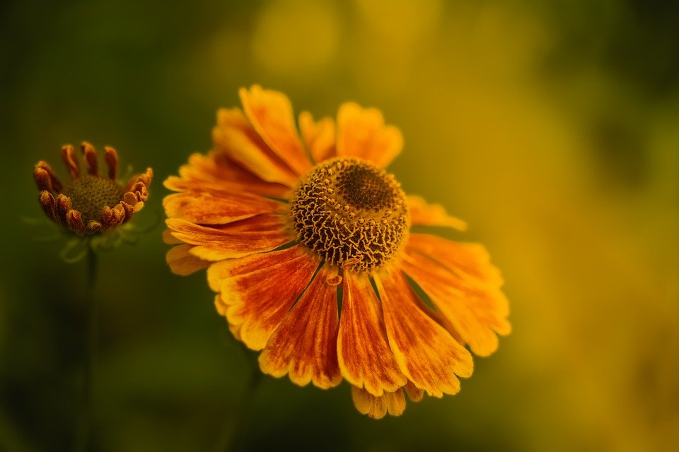

```python
# Viewing Image
Image.open(path)
```

## Get Request with URL Parameters

The GET method can be used to influence the result of your query, such as retrieving data from an API. A GET request is sent to the server. We append **/get** to the Route, as we did with the Base URL, to signal that we want to perform a GET request.

The Base URL is for http://httpbin.org/ is a simple HTTP Request & Response Service. The URL in Python is given by:

```python
url_get = 'http://httpbin.org/get'
```

A query string is a part of a uniform resource locator (URL), that sends other information to the web server.

The first parameter name is **Name** and the value is **Joseph**. The second parameter name is **ID** and the value is **123**. Each pair, parameter, and value is separated by an equals sign, **=**. The series of pairs is separated by the ampersand **&**.

To create a Query string, add a dictionary. The keys are the parameter names and the values are the value of the Query string.

```python
payload = {'name':'Joseph', 'ID':'123'}
```

Then passing the dictionary payload to the params parameter of the get() function:

```python
r_get = requests.get(url_get, params = payload)
```

We can print out the URL and see the name and values

```python
print("URL: ", r_get.url)
```

```
URL:  http://httpbin.org/get?name=Joseph&ID=123
```

Checking the request body. There is no request body!

```python
print(r_get.request.body)
```

```
None
```

Let's check the status code

```python
print(r_get.status_code)
```

```
200
```

We can view the response as text:

```python
print(r_get.text)
```

```
{
  "args": {
    "ID": "123",
    "name": "Joseph"
  },
  "headers": {
    "Accept": "*/*",
    "Accept-Encoding": "gzip, deflate",
    "Host": "httpbin.org",
    "User-Agent": "python-requests/2.28.1",
    "X-Amzn-Trace-Id": "Root=1-62e25856-616f84a9448ef9f700bfa978"
  },
  "origin": "105.112.213.113",
  "url": "http://httpbin.org/get?name=Joseph&ID=123"
}
```

We can look at the 'Content-Type':

```python
print(r_get.headers['Content-Type'])
```

```
application/json
```

As the content 'Content-Type' is in the **JSON** format we can use the method json(), it returns a Python dict:

```python
print(r_get.json())
```

```
{'args': {'ID': '123', 'name': 'Joseph'}, 'headers': {'Accept': '*/*', 'Accept-Encoding': 'gzip, deflate', 'Host': 'httpbin.org', 'User-Agent': 'python-requests/2.28.1', 'X-Amzn-Trace-Id': 'Root=1-62e25856-616f84a9448ef9f700bfa978'}, 'origin': '105.112.213.113', 'url': 'http://httpbin.org/get?name=J…
```

The Key 'args' has the names/keys and values.

```python
print(r_get.json()['args'])
```

```
{'ID': '123', 'name': 'Joseph'}
```

## Post Request

Like a GET request, a POST is used to send data to a server, but the POST request sends the data in a request body. In order to send the Post Request in Python, in the URL we change the route to POST, like this:

```python
url_post = 'http://httpbin.org/post'
```

This endpoint will expect data as a file or as a form. A form is convenient way to configure an HTTP request to send data to a server.

To make a POST request we use the post() function, the variable payload is passed to the parameter data:

```python
r_post = requests.post(url_post,data=payload)
```

Comparing the URL from the response object of the GET and POST request we see the POST request has no name or value pairs.

```python
print("POST request URL: ",r_post.url)
print("GET request URL: ",r_get.url)
```

```
POST request URL:  http://httpbin.org/post
GET request URL:  http://httpbin.org/get?name=Joseph&ID=123
```